[figure not shown]

# Combustão dos Gases do Alto Forno na Fornalha da Caldeira

# Indústria Siderúrgica

Mestrando: Moises Teles Fernandes

Orientador: Prof. Dr. Ricado C. Carpio

Co-orientador: Prof. Dr. Rogério José da Silva

Co-autor: Prof. Dr. Reginaldo Gonçalves Leão Junior

### Cuidados técnicos

Antes de executar esse *notebook* certifique-se de estar em um ambiente cujas as seguintes dependências estejam satiasfeitas.

1. Cantera
2. CoolProp
3. Matplotlib
4. Pandas
5. Champy
6. jupyter_contrib_nbextensions

**IMPORTANTE:** A compatibilidade deste notebook não foi testada em outros editores de notebooks com JupyterLab ou NBViewer.

Para maximizar a compatibilidade das funcionaldiades, recomendamos o uso do gestor de pacotes Anaconda. As especificações de instalação estão descritas abaixo.

#### Instalação do Cantera

No *anaconda prompt* em ambiente `base` use:

```
conda create --name ct-env --channel cantera cantera ipython matplotlib jupyter
```

após a instalação, feche o terminal e abra um novo e então digite a instrução abaixo para ativar o ambiente Cantera.

```
conda activate ct-env
```

#### Instalação do CoolProp

O CoolProp deve estar instalado no ambiente `ct-env` para que este notebook funcione corretamente. Caso não esteja, utilize o comando abaixo:

```
conda install -c conda-forge coolprop
```

mais detalhes técnicos da instalação podem ser obtidos em (http://www.coolprop.org/).

#### Instalação do Pandas.

A biblioteca Pandas pode ser instalada em seu ambiente `ct-env` por meio do comando:

```
conda install pandas
```

caso não esteja disponível nos canais padrão de seu ambiente utilize o comando abaixo para forçar a seleção do canal `conda-forge`:

```
conda install -c conda-forge pandas
```

#### Instalação do Chempy

A biblioteca Chempy deve ser instalada em seu ambiente `ct-env` por meio do comando:

```
conda install -c conda-forge chempy pytest
```

#### Instalação e configuração de complementos para o jupyter-notebook

Utilize a seguinte sequência de comandos em seu ambiente `ct-env` para instalar e configurar os complementos necessários do Jupyter Notebook.

```
conda install -c conda-forge jupyter_contrib_nbextensions
jupyter contrib nbextension install --user
jupyter nbextension enable python-markdown/main
```

**(Cogeração em uma Indústria Siderúrgica).** Realizar um balanço térmico para um sistema de cogeração em uma indústria siderúgica Não integrada. (Utilizando o programa COOLPROP para o cálculo das entalpias) e simular a temperatura adiabática de chama como função da vazão de gases do autoforno via CANTERA (GRIMECH3.0).

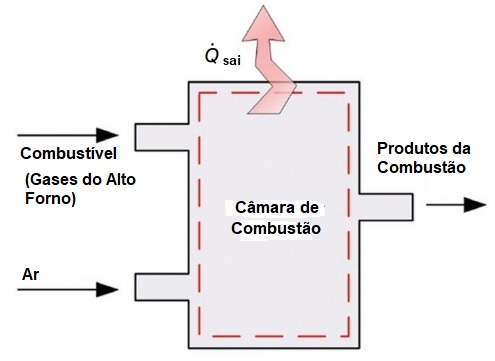

```python
import pandas as pd
from CoolProp.CoolProp import PropsSI
import matplotlib.pyplot as plt
import numpy as np
```

# DADOS DE ENTRADA

### Tabela de Composição dos Gases do Alto Forno (AF):

```python
df_composicao = pd.read_json("composicao.json", orient='split')
display(df_composicao)
```

|  | CO | H2 | H2O | CH4 | N2 | CO2 |
| --- | --- | --- | --- | --- | --- | --- |
| % em Massa | 22.15 | 5.46 | 9.88 | 1.02 | 46.73 | 14.76 |
| Massa Molar - (g/mol) | 28.00 | 2.00 | 18.00 | 16.00 | 28.00 | 44.00 |

```python
df_composicao.loc[["Massa Molar - (g/mol)"]]
```

|  | CO | H2 | H2O | CH4 | N2 | CO2 |
| --- | --- | --- | --- | --- | --- | --- |
| Massa Molar - (g/mol) | 28.0 | 2.0 | 18.0 | 16.0 | 28.0 | 44.0 |

### Parametrização Física da Simulação:

```python
# Intervalo de vazões a serem simuladas em Nm³/h
# Considere o limite superior aberto.
vaz_nm3 = [14e3, 17e3]
# Discretização do intervalo
del_vaz_nm3 = 500 # Nm³/h
# Inicialização do vetor de vazões para simulações.
vaz_nm3 = np.arange(vaz_nm3[0], vaz_nm3[1], del_vaz_nm3)

# Temperatura de entrada dos gases de auto-forno
temp_gas_af = 95 # °C
temp_gas_afSI = temp_gas_af + 273.15 # K
```

### **Dados Referentes ao combustível que entra na Caldeira:**

Tomando a *massa molecular aparente* da mistura como na forma dada pelas Equações *1.a* ou *1.b*;

$$ \large M_{ma} =\frac{1}{ \displaystyle \sum_{i=1}^{k}{\frac{f_{mas_i}}{M_i}}} \quad (1.a) $$$$ \large M_{ma} = \displaystyle \sum_{i=1}^{k}{f_{mol_i} M_i} \quad (1.b) $$

onde $M_{ma}$ é a massa molecular aparente,$M_i$, $f_{mol_i}$ e $f_{mas_i}$ são, respectivamente, a massa molar, a fração molar e a fração mássica do iésimo composto na mistura, a constante de gás $R_m$ pode ser obtida conforme a Equação *2*.

$$ \large R_m = \frac{R_u}{M_{ma}} \quad (2) $$

Além disso, adimitindo que a relação entre $f_{mas_i}$ e a $f_{mol_i}$ se dá por meio da Equação *3*.

$$ \large f_{mas_i} = f_{mol_i} \frac{M_i}{M_{ma}} \quad (3) $$

Considerando que a lei de Amagat como uma boa aproxiamação para a descrição da mistura, então o fator de compressibilidade da mistura pode ser obtido pela Equação *4*, onde $f_{mol_i}$ é a fração molar de cada um dos componentes da mistura que podem ser obtidos em `df_composicao`.

$$ \large Z_m = \displaystyle \sum^{k}_{i=1} {f_{mol_i} Z_i} \quad (4) $$

### Correção de Valores e Parametrização Vetorial

O módulo `gasmistura` contém funções que implementam o formulismo usado para a obtenção das características termodinâmicas da mistura de gases.

```python
from gasmistura_pkg import mm_aparente_mistura
help(mm_aparente_mistura)
```

```
Help on function mm_aparente_mistura in module gasmistura_pkg:

mm_aparente_mistura(compostos, mmolar, fracao, t_fracao, CNTP=True, TP=(273.153, 101325))
    Calcula a massa molecular aparente, a constante de gás e o fator de
    compressibilidade aparente de uma mistura de gases reais,
    utilizando a lei de Amagat.

    Recebe uma lista contendo as strings dos gases componentes da mistura,
    uma série de frações molares e uma string contendo o tipo da descrição
    estequimétrica:
    · "fmass" - para fração mássica;
    · "fmol" - para fração molar.

    Por padrão a função trabalha nas condições normais de temperatura e
    pressão 273,153 K e 101325 N/m². Esta condição pode ser modificada
    alterando o parâmetro padrão CNTP para False e declarando, por meio de
    uma par ordenado (list, tuple ...) os novos valores de temperatura e
    pressão no sistema internacional de unidades.

    Retorna a massa molecular aparente da mistura `mma`, a constante
    de gás da mistura `const_r_m` e o fator de compressibilidade da mistura
    `z_m`.
```

```python
mma, r_mistura, z_mistura = mm_aparente_mistura(
    compostos = list(df_composicao.columns),
    mmolar = df_composicao.loc["Massa Molar - (g/mol)"].to_numpy(),
    fracao = (df_composicao.loc["% em Massa"]).to_numpy()/100,
    t_fracao = "fmol"
)

extrato = {
    "MM Aparente": [mma],
    "Rm": [r_mistura],
    "Zm": [z_mistura]
}
extrato = pd.DataFrame(extrato)
display(extrato)
```

|  | MM Aparente | Rm | Zm |
| --- | --- | --- | --- |
| 0 | 0.136107 | 61.087546 | 4.991179 |

Considerando a lei geral dos gases ideias corrigida pelo fator de compressibilidade como uma boa aproximação para o comportamento da mistura e derivando ambos os lados da igualdade obtem-se a forma da vazão molar da mistura em uma atmosfera conforme as Equações 5.a e 5.b. $$ \large \frac{d(p V)}{dt} = \frac{(Z_m n R T)}{dt} $$

$$ \large p \dot V = Z_m R T \dot n $$$$ \large \dot n = \frac{p \dot V}{Z_m R T} \quad U[mol.s^{-1}] \quad (5.a) $$$$ \large \dot m = \frac{p \dot V}{Z_m R T} M_{ma} \quad U[kg.s^{-1}] \quad (5.b) $$

O mólduo `gasmistura` possui uma função chamada `corr_vazao_normal` que automatiza o processo de correção das vazões normais utilizando o formulismo acima.

```python
from gasmistura_pkg import corr_vazao_normal
help(corr_vazao_normal)
```

```
Help on function corr_vazao_normal in module gasmistura_pkg:

corr_vazao_normal(vaz_norm, fator_z, mmolar_ap, temp_crr, const_rm=8.314462618, press_pad=101325)
    Corrige vazões normais no SI para valores de vazão em T-p, atualmente,
    usando o fator de compressibilidade como correção para a lei geral
    dos gases ideias. Outras equações de estado podem ser implementadas
    futuramente.

    Parâmetros:
    · voz_norm - a vazão normal a ser corrigida em unidades SI;
    · factor_z - o fator de compressibilidade da mistura de gases ou do
    gás;
    · mmolar_ap - a massa molar aparente dos componentes da mistura gasosa ou d
    o gás;
    · temp_crr - temperatura absoluta no estado de correção;
    · const_rm (opcional) - a constante de gás para a correção, se não for
    for informada o valor para os gases ideiais é empregado
    (8,314 462 618 J/mol.K);

    Retornos:
    Retorna um par de valores:
    1. A vazão mássica em kg/s;
    2. A vazão molar em mol/s.
```

```python
vaz_massica, vaz_molar = corr_vazao_normal(
    vaz_norm = 4.54,
    fator_z = z_mistura,
    mmolar_ap = mma,
    temp_crr = temp_gas_afSI,
)

print(f"À temperatura de {temp_gas_afSI} K vazão mássica do gás é de {vaz_massica:.3f} kg/s e a vazão molar de {vaz_molar:.3f} mol/s.")
```

```
À temperatura de 368.15 K vazão mássica do gás é de 4.098 kg/s e a vazão molar de 30.110 mol/s.
```

# EQUAÇÃO ESTEQUIOMÉTRICA

# Equação de Balanço de Massa - EBM

### Escrevendo a equação estequiométrica (100\% de ar teórico).

\begin{equation*} \large CO + H_2 + H_2O + CH_4 + N_2 + CO_2 (AF) + (a)\big(O_2 + 3,76 N_2\big) \longrightarrow ... \end{equation*}\begin{equation*} \large ... \longrightarrow (X) CO_2 (Combustível) + CO_2 (AF) + (Y)H_2O + (Z) N_2 \end{equation*}

As vazões molares e másicas individuais podem ser determinadas simplesmente pela derivada do número de mols $n_i$ e da massa $m_i$ no tempo conforme as equações 6 e 7, onde é possível constatar que o produto das frações (mássicas e molares) pelas vazões mássica e molar do gás podem determinar as grandezas de interesse para o balançao de massa.

$$ \large \frac{d n_i}{dt} = \dot n_i = f_{mol_i} \dot n \quad(6) $$$$ \large \frac{d m_i}{dt} = \dot m_i = f_{mas_i} \dot m \quad(7) $$

Neste caso, como a composição do gás é dada em frações mássicas em `df_composicao` a Equação 3 pode ser usada para corrigir a Equação 6 na forma dada pela Equação 8.

$$ \large \dot n_i = f_{mass_i} \frac{M_{ma}}{M_i} \dot n \quad(8) $$

Com as Equações 7 e 8 definimos a dataframe `df_vazoes` que contém esses valores individuais.

```python
df_vazoes = pd.DataFrame(
    [

        df_composicao.loc["% em Massa"] / 100 * vaz_massica,
        (df_composicao.loc["% em Massa"] / 100) * (mma /  df_composicao.loc["Massa Molar - (g/mol)"]) * vaz_molar


    ],
    index=["vazao mássica individual", "vazao molar individual"]
)
df_vazoes
```

|  | CO | H2 | H2O | CH4 | N2 | CO2 |
| --- | --- | --- | --- | --- | --- | --- |
| vazao mássica individual | 0.907749 | 0.223761 | 0.404901 | 0.041802 | 1.915083 | 0.604892 |
| vazao molar individual | 0.032420 | 0.111881 | 0.022494 | 0.002613 | 0.068396 | 0.013748 |

### Equação estequiométrica com seus coeficientes:

Equação cuja a solução pode ser generalizada para:

$\large x = n° CO + n° CH_4$

$\large y = n° H_2 + n° H_2 O + 2 \cdot n° CH_4$

$\large a = \frac{n° CO}{2} + 2 \cdot n° CH_4 + \frac{n° H_2}{2}$

Um *DataFrame* para a solução dessas equações é devolvido como segundo retorno da função `vaz_combustao` que recebe como argumento `df_vazoes`, além disso a função devolve como primeiro valor a quantidade de ar (vazão) teórica para a combustão completa dos gases.

A importação da função e sua documentação é mostrada abaixo.

```python
from gasmistura_pkg import vaz_combustao
help(vaz_combustao)
```

```
Help on function vaz_combustao in module gasmistura_pkg:

vaz_combustao(dataframe)
    Realiza o balaço de massa da combustão dos gases de auto-forno.

    Parâmetros:
    · um dataframe de uma linha com os dados de vazão dos gases do
    autoforno. Na versão atual a composição deve ser limitada à:
    CO, H2, H2O, CH4, N2, CO2 e Ar. O Ar pode ser substituído por O2 e N2
    atmosféricos na forma n(O2 + 3.72 N2) quando conveniente, ou mesmo
    omitido, neste último caso, a quantidade de ar é calculada
    automaticamente.

    Retornos:
    · o dataframe dos gases de combustão com a demanda de ar-teórico caso
    este não conste no dataframe original passado como argumento
    · um segundo dataframe com os gases de combustão já balanceados em
    massa.
```

Deve-se notar que a documentação exclarece que o `dataframe` passado como argumento deve ser `um dataframe de uma linha com os dados de vazão dos gases do autoforno`.

A extração desses valores pode ser feita como:

```python
df_vazoes.iloc[1,:].to_frame().transpose()
```

|  | CO | H2 | H2O | CH4 | N2 | CO2 |
| --- | --- | --- | --- | --- | --- | --- |
| vazao molar individual | 0.03242 | 0.111881 | 0.022494 | 0.002613 | 0.068396 | 0.013748 |

```python
df_vazoes, df_vaz_comb = vaz_combustao(df_vazoes.iloc[1,:].to_frame().transpose())
display(df_vazoes)
display(df_vaz_comb)
```

|  | CO | H2 | H2O | CH4 | N2 | CO2 | O2 |
| --- | --- | --- | --- | --- | --- | --- | --- |
| vazao molar individual | 0.03242 | 0.111881 | 0.022494 | 0.002613 | 0.356232 | 0.013748 | 0.077375 |

|  | CO2 | H2O | N2 |
| --- | --- | --- | --- |
| vazao molar individual | 0.035032 | 0.1396 | 0.356232 |

No código anterior o `dataframe` `df_vazoes`é extendido para a inserção do $O_2$ atmosférico teórico e a modificação do montante de $N_2$. Além disso, a variável `df_vaz_comb` contém o dataframe com a composição dos gases de combustão.

### Equação estequiométrica completa com os respetivos coeficientes fica:

# CÁLCULO DE $O_2$ LIVRE (EM BASE SECA)

### BALANÇO DE MASSA E ENERGIA:

\begin{equation} \large \% O_2 livre = \frac{O_2 livre}{V_{gc} + 4,76 O_2 livre} \quad (9) \end{equation}

### Dados:

\begin{equation} \large \% O_2 livre = 10\% \end{equation}\begin{equation} \large O_2 livre = 0,1908 V_{gc} \quad (10) \end{equation}

onde: $V_{gc}$ é volume dos gases de combustão em base seca

### Cálculo do Volume de Gases de Combustão ($V_{gc}$)

Pode ser determinado pelo somatório da única linha de `df_vaz_comb` e o $O_2{livre}$ pela Equação 10.

```python
vgc = df_vaz_comb.iloc[0,[0,2]].sum() # CO2 e N2
o2livre = 0.1908 * vgc
print(
    "Volume dos gases de combustão,"
    f"em base seca: ",
    round(vgc,4),
    "mols/s."
)
print(
    "O2 livre: ",
    round(o2livre,4),
    "mols/s."
)
```

```
Volume dos gases de combustão,em base seca:  0.3913 mols/s.
O2 livre:  0.0747 mols/s.
```

Considerando a necessidade adicional de $O_2$ estabelecida na Equação 10, as quantidades estequimétricas correspondentes ao ar presentes em `df_vazoes` precisam ser acrescidas desses novos valores.

Aqui atualiza-se as frações para contemplar a nova demanda de $O_2$, no entanto, antes, preserva-se a quantidade de ar teórico para a determinação posterior do excesso de ar.

```python
ar_teo = df_vazoes["O2"] # ar teórico
df_vazoes["N2"] += o2livre*3.76
df_vazoes["O2"] += o2livre
df_vazoes
```

[output not shown]

# Equação de reação considerando - O2 livre

### Equação de reação:

# Cálculo do Excesso de Ar

### Equação para calcular o excesso de Ar:

\begin{equation*} \large \% execesso-de-ar = \frac{Ar_{real}}{Ar_{teórico}} \end{equation*}

```python
ex_ar = abs(1 - df_vazoes["O2"][0]/ar_teo[0])
ex_ar *= 100
```

### Excesso de Ar será:

# Análise Energético - Equação de Balanço de Energia - EBE

# Temperatura Adiabática da Chama dentro da Fornalha

### EBE:

\begin{equation*} \large \sum_{reagentes} {\dot n_{i}[ \bar{h}^{o}_f + \bar{h}_{T} - \bar{h}_{Tref}]_{r} } = \sum_{produtos} {\dot n_{i}[ \bar{h}^{o}_f + \bar{h}_{T} - \bar{h}_{Tref}]_{p} } \end{equation*}$$\;$$\begin{equation*} \large \sum_{reagentes} {\dot n_{i}[ \bar{h}^{o}_f + \bar{h}(T) - \bar{h}(T)_{ref}]_{r} } = \sum_{produtos} {\dot n_{i}[ \bar{h}^{o}_f + \bar{h}(T) - \bar{h}(T)_{ref}]_{p} } \longrightarrow Eq.2 \end{equation*}

### Os valores de calor de formação $\bar{h}^{o}_f$ e valores da entalpia a temperatura de referência $\bar{h}_{Tref}$. Tabela A-23 - Moran.

| substância |  | $\bar{h}^{o}_f$ (kJ/kmol) |  | $\bar{h}(T){ref}$ (kJ/kmol) |
| --- | --- | --- | --- | --- |
| $CO$ |  | -110530 |  | - |
| $CH_4$ |  | -74850 |  | - |
| $O_2$ |  | 0 |  | 10809 |
| $N_2$ |  | 0 |  | 10763 |
| $CO_2$ |  | -393520 |  | 12148 |
| $H_2O$ |  | -241820 |  | 12331 |

### Aplicando a Eq.2 a cada elemento da Eq. 1:

```python
# Valores de calor de Formação:

hfCO    = -110530   # kJ/kmol
hfCH4   = -74850    # kJ/kmol
hfO2    =  0        # kJ/kmol
hfN2    =  0        # kJ/kmol
hfCO2   =  -393520  # kJ/kmol
hfH2O   =  -241820  # kJ/kmol

# Valores de temperatura de Referência

TrCO    = 0         # kJ/kmol
TrCH4   = 0         # kJ/kmol
TrO2    = 10809     # kJ/kmol
TrN2    = 10763     # kJ/kmol
TrCO2   = 12148     # kJ/kmol
TrH2O   = 12331     # kJ/kmol
```

### Substituindo os valores da tabela, aplicando a Eq.2 a cada elemento da Eq. 1:

```python
reagente = 0.0446*(hfCO) + 0.1540*(hfCH4)
produtos = 0.0482*(hfCO2 - TrCO2) + 0.1921*(hfH2O - TrH2O) + 2.0264*(-TrN2) + 0.2326*(-TrO2)
RP = reagente - produtos
print("O valor dos reagentes = ","{0:.2f}".format(reagente),'kJ/kmol')
print ("O valor dos produtos = %.3f kJ/kmol" %produtos)
print ("O valor dos reagentes menos produtos  será = %.3f kJ/kmol" %RP)
```

[output not shown]

### Podendo ser também:

# Iteração 1: Assumindo T = 1000 K

### Substituindo os valores do lado esquerdo para 1000 K. E verificando os valores da Tabela A-23 (Moran), obtemos:

\begin{equation*} \large 0,0482 \times \bar{h}_{CO_2}(1000) +0,1921 \times \bar{h}_{H_2O}(1000) + 2,0264 \times \bar{h}_{N_2}(1000) + 0,2326 \times \bar{h}_{O_2}(1000)= 76243,383 \end{equation*}$$\;$$$$\;$$\begin{equation*} \large 0,0482 \times \bar{h}_{CO_2}(42769) + 0,1921 \times \bar{h}_{H_2O}(35882) + 2,0264 \times \bar{h}_{N_2}(30129) + ... \end{equation*}\begin{equation*} \large ... + 0,2326 \times \bar{h}_{O_2}(31389)= 76243,383 \end{equation*}$$\;$$\begin{equation*} \large 77308,89 > 76243,383 \end{equation*}

```python
LE1 = 0.0482*42769 + 0.1921*35882 + 2.0264*30129 + 0.2326*31389
print("O valor do lado Esquerdo = ","{0:.2f}".format(LE1),'kJ/kmol')
```

[output not shown]

# Iteração 2: Assumindo T = 800 K

### Substituindo os valores do lado esquerdo para 800 K. E verificando os valores da Tabela A-23 (Moran), obtemos:

\begin{equation*} \large 0,0482 \times \bar{h}_{CO_2}(800) +0,1921 \times \bar{h}_{H_2O}(800) + 2,0264 \times \bar{h}_{N_2}(800) + 0,2326 \times \bar{h}_{O_2}(800)= 76243,383 \end{equation*}$$\;$$$$\;$$\begin{equation*} \large 0,0482 \times \bar{h}_{CO_2}(32179) + 0,1921 \times \bar{h}_{H_2O}(27896) + 2,0264 \times \bar{h}_{N_2}(23714) + ... \end{equation*}\begin{equation*} \large ... + 0,2326 \times \bar{h}_{O_2}(24523)= 76243,383 \end{equation*}$$\;$$\begin{equation*} \large 60667,95 < 76243,383 \end{equation*}

```python
LE2 = 0.0482*32179 + 0.1921*27896 + 2.0264*23714 + 0.2326*24523
print("O valor do lado Esquerdo = ","{0:.2f}".format(LE2),'kJ/kmol')
```

[output not shown]

# Interpolando entre T = 1000 K e T = 800 K:

| $h$ |  | T(K) |
| --- | --- | --- |
| 60667,95 |  | 800 |
| 76243,383 |  | $T$ |
| 77308,89 |  | 1000 |

# Obtemos a temperatura Adiabática de Chama.

# T = 987,19 K